# Meta-analysis of guessing accuracy studies

Sidhu, Woodin, Perlman, Winter

2025-09-26

# 1 Intro

In this script, we will perform a historical meta-analyses of the series of guessing accuracy studies that was performed under the banner of “phonetic symbolism” from the 1930’s to the 1970’s.

Load libraries:

```r
library(tidyverse)
library(tidybayes)
library(brms)
```

We’ll use `darkorchid4` as the standard fill color:

```r
default_col <- 'darkorchid4'
default_col2 <- 'lightsteelblue3'
```

Load data:

```r
met <- read_csv('../data/phonetic_symbolism_meta_analysis.csv') |>
  select(reference, year, experiment, n_sub:accuracy) # re-order

# Show random rows:

sample_n(met, 10)
```

```
## # A tibble: 10 × 8
##    reference       year experiment n_sub n_trials antonyms auditory_presentation
##    <chr>          <dbl>      <dbl> <dbl>    <dbl>    <dbl>                 <dbl>
##  1 Baindurashvil…  1967          5    50       25        1                     0
##  2 Slobin (1968)   1968          1    46       21        1                     1
##  3 Brackbill and…  1957          3    40       50        0                     0
##  4 Klank, Huang …  1971          3    40       40        0                     0
##  5 Slobin (1968)   1968          4    46       20        1                     0
##  6 Baindurashvil…  1967          6    50       25        1                     0
##  7 Weiss (1966)    1966          1   294       28        0                     0
##  8 Brackbill and…  1957          4    40       50        0                     1
##  9 Rich (1953)     1953          1    44       25       NA                     1
## 10 Klank, Huang …  1971          4    40       38        0                     0
## # ℹ 1 more variable: accuracy <dbl>
```

This data contains:

- the `reference` of the initial publication
- a numerical identifier for the `experiment` within each publication
- the publication `year`
- the number of subjects `n_sub`
- the number of trials `n_trials`
- whether the study only included `antonyms`
- the modality with which stimuli were presented: `auditory_presentation` (0 = written, 1 = auditory)
- the guessing `accuracy`, our main DV

# 2 Preprocessing

The main DV, `accuracy`, is a percentage, which is a continuous variable that is bounded by [0%, 100%]. A sensible data-generating process for such data would be the beta distribution.

For the Bayesian beta regression model below, we’ll have to convert `accuracy` to be a [0, 1] bounded variable>

```r
met <- met |>
  mutate(acc_01 = accuracy / 100)

# Check:

met |> select(accuracy, acc_01)
```

```
## # A tibble: 57 × 2
##    accuracy acc_01
##       <dbl>  <dbl>
##  1     50.2  0.501
##  2     56.0  0.560
##  3     60.3  0.603
##  4     57.0  0.570
##  5     59.8  0.598
##  6     60.9  0.609
##  7     58    0.58
##  8     63    0.63
##  9     57    0.57
## 10     56.6  0.566
## # ℹ 47 more rows
```

# 3 Overview

This sections gives an overview of the dataset, answering such questions as:

- How many publications, experiments, subjects, and trials do we have?
- How many experiments do we have?
- How many experiments included antonyms?
- How many used auditory or written presentation?

```r
met |> count(reference, sort = TRUE)
```

```
## # A tibble: 14 × 2
##    reference                                  n
##    <chr>                                  <int>
##  1 Baindurashvili (1967)                     10
##  2 Brackbill and Little (1957)                6
##  3 Klank, Huang & Johnson (1971)              6
##  4 Siegel, Silverman, & Markel (1967)         6
##  5 Brown and Nuttall (1959)                   5
##  6 Slobin (1968)                              5
##  7 Maltzman, Morrisett, and Brooks (1956)     4
##  8 Weiss (1963)                               4
##  9 Brown, Black, and Horowitz (1955)          3
## 10 Kunihara (1971)                            3
## 11 Rich (1953)                                2
## 12 Allport (1935)                             1
## 13 McMurray (1960)                            1
## 14 Weiss (1966)                               1
```

14 studies in total.

What’s the total number of experiments, and the average number of experiments?

```r
met |>
  count(reference) |>
  summarize(total = sum(n),      # total number of experiments
            average = mean(n))   # average number of experiments
```

```
## # A tibble: 1 × 2
##   total average
##   <int>   <dbl>
## 1    57    4.07
```

We have a total of 57(!) experiments in this dataset. That’s quite nice.

On average, each study has about 4 experiments. The good old days!

How many subjects do we have in total? And how many subjects does each study have on average?

```r
met |>
  summarize(n_total = sum(n_sub, na.rm = TRUE),
            n_average = mean(n_sub, na.rm = TRUE),
            min_sub = min(n_sub, na.rm = TRUE),
            max_sub = max(n_sub, na.rm = TRUE))
```

```
## # A tibble: 1 × 4
##   n_total n_average min_sub max_sub
##     <dbl>     <dbl>   <dbl>   <dbl>
## 1    3366      60.1      29     294
```

A total of 3,366 participants across studies, on average ~60 per experiment. The smallest study has only 29 participants, the biggest one 294.

This is an undercount because Allport (1935) does not report how many people participated in the experiment.

Let’s look at the number of trials:

```r
met |>
  summarize(n_total = sum(n_trials, na.rm = TRUE),
            n_average = mean(n_trials, na.rm = TRUE))
```

```
## # A tibble: 1 × 2
##   n_total n_average
##     <dbl>     <dbl>
## 1    1627      28.5
```

A total of 1627 trials across experiments (on average 28.5 per experiment), which multiplied by the number of participants yields:

```r
1627 * 3366
```

```
## [1] 5476482
```

Our data is based on a whopping 5,476,482 (~5.5 million) data points. Again, this must be a slight undercount given that we don’t have the participant figures for Allport (1935).

How many experiments used antonyms?

```r
met |>
  count(antonyms) |>
  mutate(p = n / sum(n),
         perc = round(p, 3) * 100,
         perc = str_c(perc, '%'))
```

```
## # A tibble: 3 × 4
##   antonyms     n      p perc
##      <dbl> <int>  <dbl> <chr>
## 1        0    15 0.263  26.3%
## 2        1    39 0.684  68.4%
## 3       NA     3 0.0526 5.3%
```

More than two thirds of the studies (68.4%) tested antonyms. For 3 experiments (5.3% of the data), we do not know what kinds of stimuli were tested.

How many experiments used auditory versus written presentations?

```r
met |>
  count(auditory_presentation) |>
  mutate(p = n / sum(n),
         perc = round(p, 3) * 100,
         perc = str_c(perc, '%'))
```

```
## # A tibble: 3 × 4
##   auditory_presentation     n      p perc
##                   <dbl> <int>  <dbl> <chr>
## 1                     0    31 0.544  54.4%
## 2                     1    25 0.439  43.9%
## 3                    NA     1 0.0175 1.8%
```

A little more than half (54.4%) used written presentation, with slightly fewer using auditory presentation (43.9%).

Let’s look at whether there are more or less subjects over time, or more or less trials. We can color-code the data points for `antonyms` and map the `shape` of each point onto `auditory_presentation`.

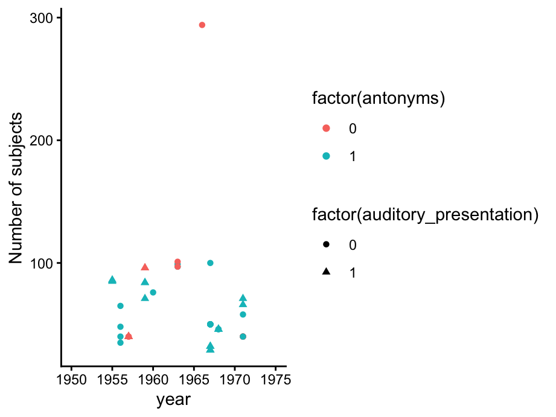

```r
met |>
  filter(!is.na(antonyms),
         !is.na(auditory_presentation)) |>
  ggplot(aes(x = year, y = n_sub)) +
  geom_point(aes(color = factor(antonyms), shape = factor(auditory_presentation))) +
  scale_x_continuous(limits = c(1950, 1975)) +
  ylab('Number of subjects') +
  theme_classic()
```

No real patterns here. Let’s do the same for the number of trials:

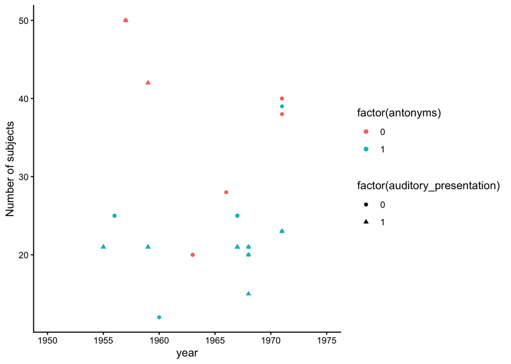

```r
met |>
  filter(!is.na(antonyms),
         !is.na(auditory_presentation)) |>
  ggplot(aes(x = year, y = n_trials)) +
  geom_point(aes(color = factor(antonyms), shape = factor(auditory_presentation))) +
  scale_x_continuous(limits = c(1950, 1975)) +
  ylab('Number of subjects') +
  theme_classic()
```

Also no clear trend.

# 4 Descriptive statistics

Let’s compute the average accuracy across all studies (grand average):

```r
met |> summarize(M = mean(accuracy))
```

```
## # A tibble: 1 × 1
##       M
##   <dbl>
## 1  56.9
```

The average across all studies is 56.9%.

Check descriptively whether `antonyms` makes a difference:

```r
met |>
  filter(!is.na(antonyms)) |>
  group_by(antonyms) |>
  summarize(M = mean(accuracy))
```

```
## # A tibble: 2 × 2
##   antonyms     M
##      <dbl> <dbl>
## 1        0  53.0
## 2        1  58.2
```

Studies that test antonyms are 5.2% higher in average accuracy.

Check descriptively whether `auditory_presentation` makes a difference:

```r
met |>
  filter(!is.na(auditory_presentation)) |>
  group_by(auditory_presentation) |>
  summarize(M = mean(accuracy))
```

```
## # A tibble: 2 × 2
##   auditory_presentation     M
##                   <dbl> <dbl>
## 1                     0  56.9
## 2                     1  56.9
```

Exactly equal. Doesn’t seem to make any difference.

# 5 Data visualization

## 5.1 Studies over time

Make a plot of studies over time:

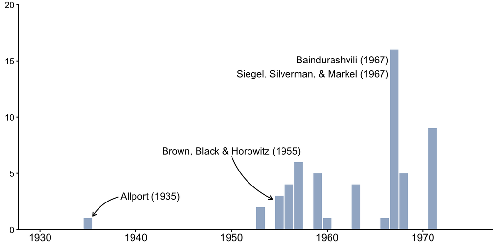

```r
# Plot core:

year_p <- met |>
  count(year) |>
  ggplot(aes(x = year, y = n)) +
  geom_col(fill = default_col2)

# Axes, labels and cosmetics:

year_p <- year_p +
  xlab(NULL) +
  ylab(NULL) +
  scale_x_continuous(breaks = seq(1930, 1970, 10),
                     limits = c(1930, 1975))+
  scale_y_continuous(breaks = seq(0, 20, 5),
                     limits = c(0, 20),
                     expand = c(0, 0)) +
  theme_classic() +
  theme(axis.text.x = element_text(size = 12),
        axis.text.y = element_text(size = 10))

# Annotations:

year_p <- year_p +
  # Allport 1935

  annotate('text', x = 1941.5, y = 3,
           label = 'Allport (1935)',
           hjust = 0.5, size = 4) +
  annotate('curve', x = 1938.2, y = 2.9,
           xend = 1935.5, yend = 1.2,
           curvature = +0.2,
           arrow = arrow(length = unit(5, 'pt')),
           linewidth = 0.5) +

  # Brown, Black & Horowitz (1955)

  annotate('text', x = 1950, y = 8 - 1,
           xend = 1954.5, yend = 3.5,
           label = 'Brown, Black & Horowitz (1955)',
           hjust = 0.5, size = 4) +
  annotate('curve', x = 1950, y = 7.5 -1,
           xend = 1954.3, yend = 2.7,
           curvature = +0.2,
           arrow = arrow(length = unit(5, 'pt')),
           linewidth = 0.5) +

  # Baindurashvili (1967) & Siegel, Silverman, & Markel (1967)

  annotate('text', x = 1966.4, y = 14.5,
           label = 'Baindurashvili (1967)\nSiegel, Silverman, & Markel (1967)',
           hjust = 1, size = 4)
# Show and save:

year_p
```

```r
ggsave(plot = year_p,
       filename = '../figures/png/meta_studies_over_time.png',
       width = 8, height = 4)
```

## 5.2 Average accuracy

Peaking ahead

**Note:** Change order later.

```r
x <- seq(35, 80, length.out = 1000)

prior_df <- tibble(accuracy = x,
                   density = dt((qlogis(x / 100) - 0) / 0.1724, df = 3) / 0.1724 * (1 / ((x / 100) * (1 - x / 100))) / 100) |>
  mutate(density = density * 2) # scale for plot
```

Let’s make a density plot of the distribution of accuracy values across studies:

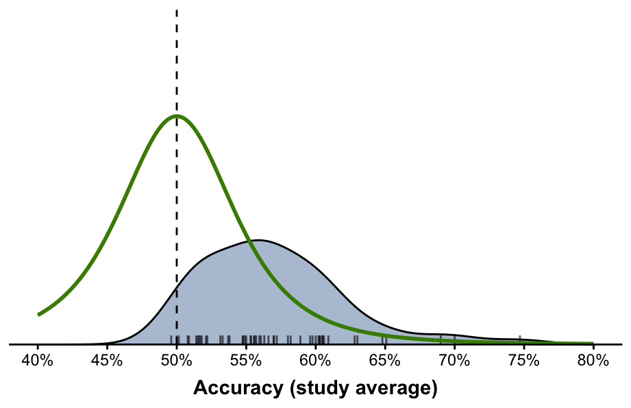

```r
# Plot core:

dens_p <- met |>
  ggplot(aes(x = accuracy)) +
  geom_density(fill = default_col2, alpha = 0.8) +
  geom_vline(xintercept = 50, linetype = 'dashed') +
  geom_rug(alpha = 0.6, length = unit(0.027, 'npc'))

# Scales, axes, and annotations:

dens_p <- dens_p +
  scale_x_continuous(limits = c(40, 80),
                     breaks = seq(40, 80, 5),
                     labels = str_c(seq(40, 80, 5), '%')) +
  # scale_y_continuous(expand = c(0, 0), limits = c(0, 0.10),
  #                    breaks = seq(0, 0.10, 0.02)) +
  scale_y_continuous(expand = c(0, 0), limits = c(0, 0.25), # for later transition
                     breaks = seq(0, 0.25, 0.05)) +
  xlab('Accuracy (study average)') +
  # ylab('Probability density') +
  ylab(NULL) +
  NULL
  # annotate('text', x = 49.6, y = 0.09,
  #          label = '50% chance\nbaseline',
  #          hjust = 1,
  #          size = 3)

# Visualize intercept prior on this:

dens_p <- dens_p +
  geom_line(data = prior_df,
            mapping = aes(x = accuracy, y = density),
            linewidth = 1, col = 'chartreuse4')

# Plot cosmetics:

dens_p <- dens_p +
  theme_classic() +
  theme(axis.title.x = element_text(face = 'bold', margin = margin(t = 6))) +
  # theme(axis.title.y = element_text(margin = margin(r = 10))) +
  theme(axis.line.y = element_blank(),
        axis.ticks.y = element_blank(),
        axis.text.y = element_blank()) +
  coord_cartesian(clip = 'off')

# Show and save:

dens_p
```

```r
ggsave('../figures/pdf/meta_analysis_density_plot.pdf',
       width = 6, height = 2.8)
ggsave('../figures/png/meta_analysis_density_plot.png',
       width = 6, height = 2.8)
```

# 6 Modeling

## 6.1 Grand average, no fixed effects, unweighted

The model will contain a `(1|reference)` random intercept, i.e., it is a random effects meta-analysis allowing for some studies to have on average higher or lower accuracies. The random effect variation is likely going to be inflated in this model because `(1|reference)` masks the contribution of the `antonyms` and `auditory_presentation` variables, e.g., some references include only antonyms (e.g., Baindurashvili 1967), and others only test non-antonyms (e.g., Brackbill and Little 1957).

In this first analysis, we’ll now weight by `n_sub`, i.e., each study will be treated equally. Later we’ll look at how things appear when we allow bigger studies to contribute more towards the mean using a weighted beta regression.

### 6.1.1 Prior specification

`brms` would set a `student_t(3, 0, 2.5)` prior on the intercept by default. Let’s visualize this prior:

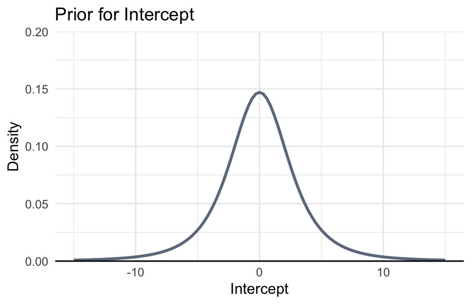

```r
# Plot core:

ggplot(data = tibble(x = c(-15, 15)),
       mapping = aes(x)) +
  stat_function(fun = function(x) dt((x - 0) / 2.5, df = 3) / 2.5,
                color = "lightsteelblue4",
                linewidth = 1) +

# Axes and labels:

  labs(title = "Prior for Intercept",
       y = "Density",
       x = "Intercept") +
  scale_y_continuous(expand = c(0, 0),
                     limits = c(0, 0.2)) +

# Cosmetics:

  theme_minimal() +
  theme(axis.line.x = element_line())
```

This is on the logit scale, since beta regression uses a `mu = logit` link. The graph suggests that this prior would seem to be very agnostic. Even very high and low logit values, e.g., -8/+8, have quite high probability mass, which would correspond to accuracies of:

```r
# Check logit values -8, +8

plogis(-8)
```

```
## [1] 0.0003353501
```

```r
plogis(+8)
```

```
## [1] 0.9996646
```

```r
# Check logit values -5, +5

plogis(-5)
```

```
## [1] 0.006692851
```

```r
plogis(+5)
```

```
## [1] 0.9933071
```

Yeah, this prior definitely puts too much probability mass on extreme values.

This judgment is based on multiple factors:

- lived experience tells us that when we listen to foreign languages we don’t know, we cannot really understand anything unless the languages are closely related
- Dingemanse et al. (2016), a study that tested guessing accuracy of ideophones - largely independent of this research on phonetic symbolism - achieved ~55% accuracy in a binary forced choice task, and that’s for words that very iconic to native speakers, which are pretty much our “best bet” for being guessable at all
- linguistic theory tells us that form-meaning mappings are largely conventional (e.g., Saussure), and even if we assume that all words ultimately may have iconic origins, de-iconization is likely going to have eroded much of that to levels that are not accessible to foreigners

All of this warrants a tighter intercept. I’d say that as a good first bet, putting the 95% probability mass onto the range [40%, 60%] seems sensible. This basically says: all else being equal, we expect 50% chance performance in a binary forced choice task, and 60% would be surprisingly good performance for conventional words.

With a little help from our friend ChatGPT, and keeping degrees of freedom = 3 for reasonably heavy tails, we need to find the right sigma.

```r
# Find sigma that is 95% at 60%:

sigma <- qlogis(0.6) / qt(0.975, df = 3)

# Check if it maps to [0.4, 0.6]:


plogis( qt(c(.025, .975), df = 3) * sigma )
```

```
## [1] 0.4 0.6
```

Yup, it does. Nice. Let’s visualize this prior now.

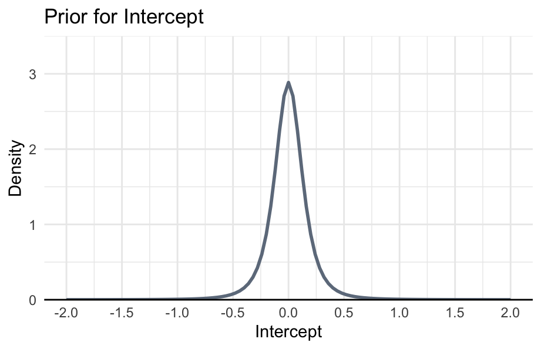

```r
# Plot core:

ggplot(data = tibble(x = c(-15, 15)),
       mapping = aes(x)) +
  stat_function(fun = function(x) dt((x - 0) / sigma, df = 3) / sigma, # new value
                color = "lightsteelblue4",
                linewidth = 1) +

# Axes and labels:

  labs(title = "Prior for Intercept",
       y = "Density",
       x = "Intercept") +
  scale_x_continuous(limits = c(-2, +2),
                     breaks = seq(-2, 2, 0.5)) +
  scale_y_continuous(expand = c(0, 0),
                     limits = c(0, 3.5)) +

# Cosmetics:

  theme_minimal() +
  theme(axis.line.x = element_line())
```

Next, let’s think about the random intercept prior. As a hunch, I’d be very surprised if one study had, say, +20% more accuracy than another. But because different studies use very different sets of words, different languages (sometimes not related at all, sometimes from a different genus of the Indo-European family), and use different tasks (e.g., antonyms, which are probably easier), the accuracy variation is probably bigger.

For our intercept, sigma is at:

```r
sigma
```

```
## [1] 0.1274067
```

I’d say that a sigma double than that is probably a good first bet.

```r
plogis(qt(c(.025, .975), df = 3) * (sigma * 2))
```

```
## [1] 0.3076923 0.6923077
```

So, let’s set the priors. For the phi parameter we will use the very agnostic `brms` default `gamma(0.01, 0.01)`:

```r
met_priors <- c(prior(student_t(3, 0, 0.1274067), class = 'Intercept'),
                prior(student_t(3, 0, 0.2548134), class = 'sd'),
                prior(gamma(0.01, 0.01), class = 'phi'))
```

### 6.1.2 Fit intercept-only model

Now run the model. We set `eval = FALSE` in the code chunk options because models will be pre-compiled before knitting to save time.

Important side note: to facilitate later comparison with the weighted model, I am fitting this model without the single Allenport (1935) data point for which we are missing `n_sub`. I’ve checked, and it makes pretty much no difference (only a couple decimals), so our conclusions don’t change much, but otherwise we can’t compare the models because they’d be fitted to different datasets.

```r
meta_mdl <- brm(acc_01 ~ 1 + (1|reference),
                data = filter(met, !is.na(n_sub)),
                family = Beta(),
                prior = met_priors,

                # MCMC settings:

                save_pars = save_pars(all = TRUE),
                cores = 4, chains = 4,
                iter = 12000, warmup = 4000, thin = 1,
                seed = 42)

# Save:

saveRDS(meta_mdl, file = '../models/meta_analysis_intercept_only_unweighted.rds')
```

Load this now with `eval = TRUE` so that it is available for knitting:

```r
meta_mdl <- readRDS('../models/meta_analysis_intercept_only_unweighted.rds')
```

Double-check that priors have been correctly applied:

```r
prior_summary(meta_mdl)
```

```
##                       prior     class      coef     group resp dpar nlpar lb ub
##  student_t(3, 0, 0.1274067) Intercept
##           gamma(0.01, 0.01)       phi                                      0
##  student_t(3, 0, 0.2548134)        sd                                      0
##  student_t(3, 0, 0.2548134)        sd           reference                  0
##  student_t(3, 0, 0.2548134)        sd Intercept reference                  0
##  tag       source
##              user
##              user
##              user
##      (vectorized)
##      (vectorized)
```

Check MCMC plots to visually assess whether chains are mixing well, as well as first plot of posterior distribution:

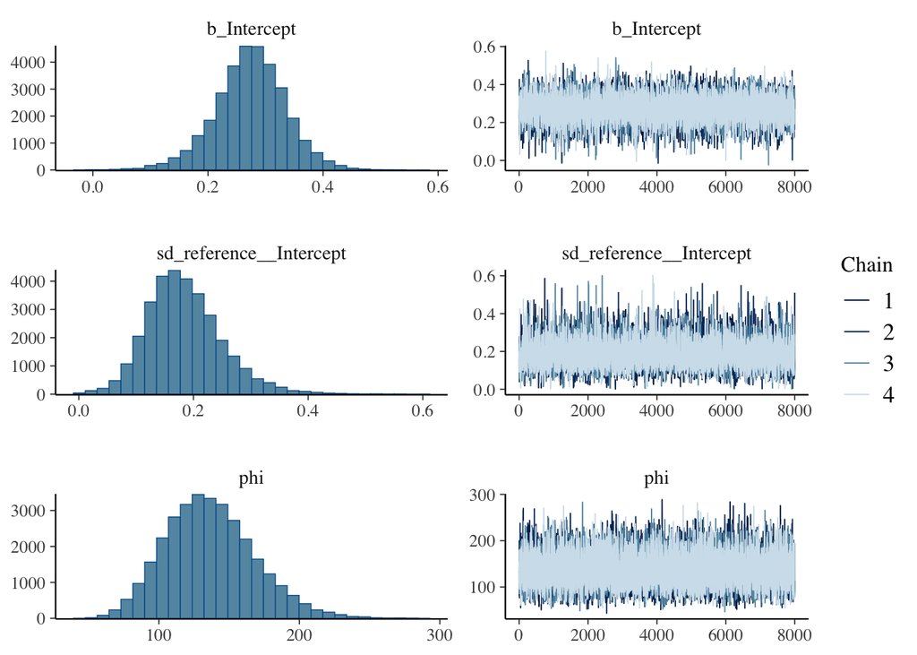

```r
plot(meta_mdl)
```

Looks good.

Check posterior predictive simulations:

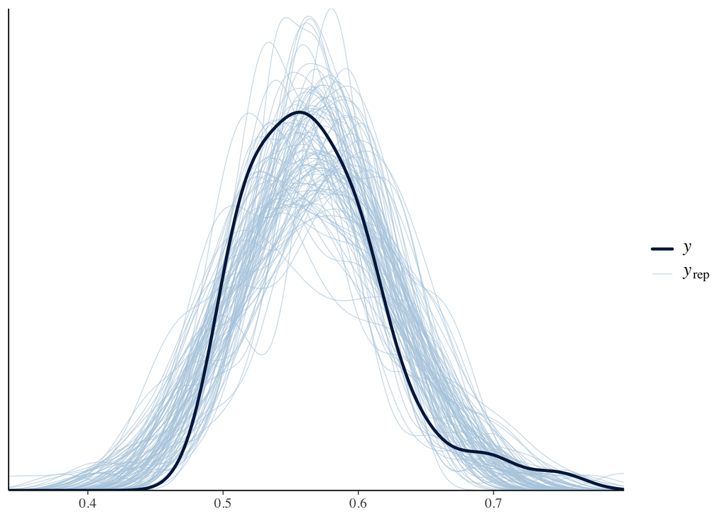

```r
pp_check(meta_mdl, ndraws = 100)
```

Decent.

Show the model:

```r
meta_mdl
```

```
##  Family: beta
##   Links: mu = logit
## Formula: acc_01 ~ 1 + (1 | reference)
##    Data: filter(met, !is.na(n_sub)) (Number of observations: 56)
##   Draws: 4 chains, each with iter = 12000; warmup = 4000; thin = 1;
##          total post-warmup draws = 32000
##
## Multilevel Hyperparameters:
## ~reference (Number of levels: 13)
##               Estimate Est.Error l-95% CI u-95% CI Rhat Bulk_ESS Tail_ESS
## sd(Intercept)     0.18      0.07     0.07     0.33 1.00     5679     8538
##
## Regression Coefficients:
##           Estimate Est.Error l-95% CI u-95% CI Rhat Bulk_ESS Tail_ESS
## Intercept     0.27      0.06     0.14     0.39 1.00     8809    10502
##
## Further Distributional Parameters:
##     Estimate Est.Error l-95% CI u-95% CI Rhat Bulk_ESS Tail_ESS
## phi   136.57     31.85    80.42   204.46 1.00    11991    15037
##
## Draws were sampled using sampling(NUTS). For each parameter, Bulk_ESS
## and Tail_ESS are effective sample size measures, and Rhat is the potential
## scale reduction factor on split chains (at convergence, Rhat = 1).
```

What does our model predict on the proportion scale in terms of the posterior mean and 95% credible interval?

We want the marginal posterior mean and 95% interval, integrated over the random effects distribution, not conditioning on any specific group:

```r
# Setup new data:

new_data <- tibble(group = 'NEW')

# Draws from expected value of the posterior distribution:

ep <- posterior_epred(meta_mdl,
                      newdata = new_data,
                      allow_new_levels = TRUE,
                      sample_new_levels = 'gaussian')

# Summaries:

mean(ep)              # posterior mean
```

```
## [1] 0.5674458
```

```r
quantile(ep, 0.025)   # 95% credible interval, lower bound
```

```
##      2.5%
## 0.4623457
```

```r
quantile(ep, 0.975)   # 95% credible interval, upper bound
```

```
##     97.5%
## 0.6662132
```

What is the probability that the intercept, in its logit value, is above 50%? We’ll do a simple test of same sign here - it’s not clear what a sensible ROPE would be.

```r
hypothesis(meta_mdl, 'Intercept > 0')
```

```
## Hypothesis Tests for class b:
##        Hypothesis Estimate Est.Error CI.Lower CI.Upper Evid.Ratio Post.Prob
## 1 (Intercept) > 0     0.27      0.06     0.17     0.37    5332.33         1
##   Star
## 1    *
## ---
## 'CI': 90%-CI for one-sided and 95%-CI for two-sided hypotheses.
## '*': For one-sided hypotheses, the posterior probability exceeds 95%;
## for two-sided hypotheses, the value tested against lies outside the 95%-CI.
## Posterior probabilities of point hypotheses assume equal prior probabilities.
```

Given this model, priors and data, we can be 100% certain that the average is above 50%, that is, 100% of all posterior samples are above that threshold.

## 6.2 Weighted regression

Now we want to apply regression weights that penalize small-sample studies relative to large-sample studies, which should count more towards the mean.

```r
weighted_mdl <- brm(acc_01 | weights(n_sub) ~ 1 + (1|reference),
                    data = filter(met, !is.na(n_sub)),
                    family = Beta(),
                    prior = met_priors,

                    # MCMC settings:

                    save_pars = save_pars(all = TRUE),
                    cores = 4, chains = 4,
                    iter = 12000, warmup = 4000, thin = 1,
                    seed = 42)

# Save:

saveRDS(weighted_mdl, file = '../models/meta_analysis_intercept_only_weighted.rds')
```

Load this now with `eval = TRUE` so that it is available for knitting:

```r
weighted_mdl <- readRDS('../models/meta_analysis_intercept_only_weighted.rds')
```

Double-check that priors have been correctly applied:

```r
prior_summary(weighted_mdl)
```

```
##                       prior     class      coef     group resp dpar nlpar lb ub
##  student_t(3, 0, 0.1274067) Intercept
##           gamma(0.01, 0.01)       phi                                      0
##  student_t(3, 0, 0.2548134)        sd                                      0
##  student_t(3, 0, 0.2548134)        sd           reference                  0
##  student_t(3, 0, 0.2548134)        sd Intercept reference                  0
##  tag       source
##              user
##              user
##              user
##      (vectorized)
##      (vectorized)
```

Check MCMC plots to visually assess whether chains are mixing well, as well as first plot of posterior distribution:

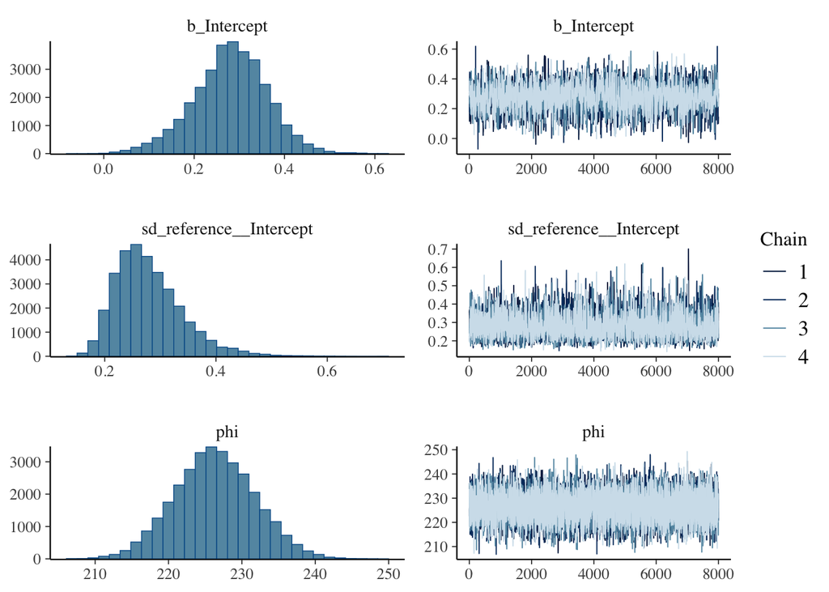

```r
plot(weighted_mdl)
```

Looks good again. The scale of the phi parameter has changed massively, but that’s just because we didn’t mean-center the weights and since we’re not interested in phi, that’s OK here.

Check posterior predictive simulations:

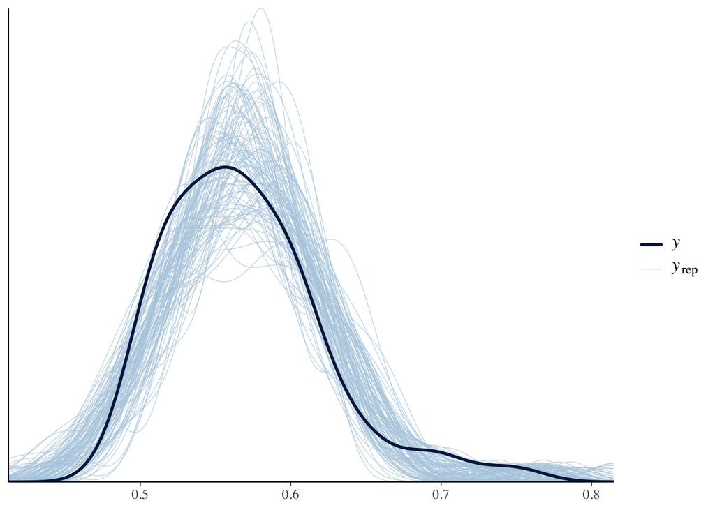

```r
pp_check(weighted_mdl, ndraws = 100)
```

Decent again.

Show the model:

```r
weighted_mdl
```

```
##  Family: beta
##   Links: mu = logit
## Formula: acc_01 | weights(n_sub) ~ 1 + (1 | reference)
##    Data: filter(met, !is.na(n_sub)) (Number of observations: 56)
##   Draws: 4 chains, each with iter = 12000; warmup = 4000; thin = 1;
##          total post-warmup draws = 32000
##
## Multilevel Hyperparameters:
## ~reference (Number of levels: 13)
##               Estimate Est.Error l-95% CI u-95% CI Rhat Bulk_ESS Tail_ESS
## sd(Intercept)     0.28      0.06     0.19     0.42 1.00     3247     5927
##
## Regression Coefficients:
##           Estimate Est.Error l-95% CI u-95% CI Rhat Bulk_ESS Tail_ESS
## Intercept     0.28      0.08     0.11     0.44 1.00     2382     3577
##
## Further Distributional Parameters:
##     Estimate Est.Error l-95% CI u-95% CI Rhat Bulk_ESS Tail_ESS
## phi   226.34      5.50   215.77   237.17 1.00     9337     9407
##
## Draws were sampled using sampling(NUTS). For each parameter, Bulk_ESS
## and Tail_ESS are effective sample size measures, and Rhat is the potential
## scale reduction factor on split chains (at convergence, Rhat = 1).
```

Same as above, marginal posterior mean and 95% interval, not conditioning on any specific group:

```r
# Draws from expected value of the posterior distribution:

ep <- posterior_epred(weighted_mdl,
                      newdata = new_data,
                      allow_new_levels = TRUE,
                      sample_new_levels = 'gaussian')

# Summaries:

mean(ep)              # posterior mean
```

```
## [1] 0.5687238
```

```r
quantile(ep, 0.025)   # 95% credible interval, lower bound
```

```
##      2.5%
## 0.4209608
```

```r
quantile(ep, 0.975)   # 95% credible interval, upper bound
```

```
##     97.5%
## 0.7020807
```

What is the probability that the intercept, in its logit value, is above 50%? We’ll do a simple test of same sign here - it’s not clear what a sensible ROPE would be.

```r
hypothesis(weighted_mdl, 'Intercept > 0')
```

```
## Hypothesis Tests for class b:
##        Hypothesis Estimate Est.Error CI.Lower CI.Upper Evid.Ratio Post.Prob
## 1 (Intercept) > 0     0.28      0.08     0.14     0.41    3554.56         1
##   Star
## 1    *
## ---
## 'CI': 90%-CI for one-sided and 95%-CI for two-sided hypotheses.
## '*': For one-sided hypotheses, the posterior probability exceeds 95%;
## for two-sided hypotheses, the value tested against lies outside the 95%-CI.
## Posterior probabilities of point hypotheses assume equal prior probabilities.
```

Again, super certain it’s above 50%.

### 6.2.1 Model comparison

Let’s compare the weighted and unweighted models in terms of their predictive power, using LOO-CV:

```r
# loo_unweighted <- loo(meta_mdl, reloo = TRUE)
# loo_weighted <- loo(weighted_mdl, reloo = TRUE)
#
# saveRDS(loo_unweighted, '../models/loo_cv_objects/meta_loo_unweighted.rds')
# saveRDS(loo_weighted, '../models/loo_cv_objects/meta_loo_unweighted.rds')
```

**Note**: For `weighted_mdl`: `7 problematic observation(s) found. The model will be refit 7 times.` **Note 2**: I *still* get this warning: `Warning messages: 1: Ignoring relative efficiencies as some were NA. See argument 'r_eff' in ?loo::loo for more details. 2: Some Pareto k diagnostic values are too high. See help('pareto-k-diagnostic') for details.`

Load and compare:

```r
# loo_unweighted <- readRDS('../models/loo_cv_objects/meta_loo_unweighted.rds')
# loo_weighted <- readRDS('../models/loo_cv_objects/meta_loo_unweighted.rds')
#
# loo_compare(loo_unweighted, loo_weighted)
```

**Note**: Be careful though given the warning messages above. **Note**: With the higher post-warmup iterations it doesn’t run anymore due to 500 Mb constraint. So, lots of issues with this -> we’ll work with the k-fold cross-validation.

K-fold cross-validation as loo compare seems to have issues:

```r
k10_weighted <- kfold(weighted_mdl, K = 10, save_fits = TRUE)
k10_unweighted <- kfold(meta_mdl, K = 10, save_fits = TRUE)

saveRDS(k10_weighted, '../models/loo_cv_objects/meta_k10_weighted.rds')
saveRDS(k10_unweighted, '../models/loo_cv_objects/meta_k10_unweighted.rds')
```

Load and compare:

```r
k10_weighted <- readRDS('../models/loo_cv_objects/meta_k10_weighted.rds')
k10_unweighted <- readRDS('../models/loo_cv_objects/meta_k10_unweighted.rds')

loo_compare(k10_weighted, k10_unweighted)
```

```
##              elpd_diff se_diff
## weighted_mdl     0.0       0.0
## meta_mdl     -5873.1     828.5
```

## 6.3 Model with fixed effects

### 6.3.1 Prior specification

Let’s add the antonym and auditory presentation fixed effects. This means that we now need to also specify priors for the coefficient slopes.

Here, I’m going to use the same reasonign that is explicated in `experiment_analysis` for the size of the SD of the student-t distributed prior for the slope (I did that analysis before this one). This works because we’re also working with the assumption that things are around 50% and that a 10% change is a big change and should be at the fringe of our expectations (we’re finding the logit value that is 40%/60%).

```r
met_priors_b <- c(prior(student_t(3, 0, 0.1274067), class = 'Intercept'),
                  prior(student_t(3, 0, 0.1274067), class = 'b'),
                  prior(student_t(3, 0, 0.2548134), class = 'sd'),
                  prior(gamma(0.01, 0.01), class = 'phi'))
```

### 6.3.2 Fit fixed-effects model

As the intercept-only model has shown that the weighted model is massively preferred as per LOO-CV, we’ll go ahead with that and don’t consider the unweighted model anymore. From now on, all models will include regression weights for the number of subjects.

We’ll want to compare the different models (with or without `antonyms` and/or `auditory_presentation`) with each other, so we need to make sure that they’re fitted to the same data.

Since some tags are `NA` for either `antonyms` or `auditory_presentation`, we need to get the subset that has no `NA` for any of these:

```r
met_red <- met |>
  filter(!is.na(antonyms),
         !is.na(auditory_presentation),
         !is.na(n_sub))
```

It would be nice to test the intercept (average guessing accuracy) in a model that controls for antonyms and auditory presentation. For this we want to create sum-codes that are fractional / weighted by how many cases there are, given that we have an unequal number of studies with/without antonyms or auditory presentation.

Check the percentages again in the new no-`NA` tibble:

```r
# Antonyms:

met_red |>
  count(antonyms) |>
  mutate(p = n / sum(n))
```

```
## # A tibble: 2 × 3
##   antonyms     n     p
##      <dbl> <int> <dbl>
## 1        0    15 0.278
## 2        1    39 0.722
```

```r
# Auditory presentation:

met_red |>
  count(auditory_presentation) |>
  mutate(p = n / sum(n))
```

```
## # A tibble: 2 × 3
##   auditory_presentation     n     p
##                   <dbl> <int> <dbl>
## 1                     0    31 0.574
## 2                     1    23 0.426
```

Now assign the weighted effect coding:

```r
met_red <- met_red |>
  mutate(antonyms_weighted = if_else(antonyms == 0, -0.722, +0.278),
         auditory_weighted = if_else(auditory_presentation == 0, -0.426, +0.574))

# Sanity checks:

0.278 * (-0.722) + 0.722 * (+0.278)
```

```
## [1] 0
```

```r
0.574 * (-0.426) + 0.426 * (+0.574)
```

```
## [1] 0
```

```r
with(met_red, weighted.mean(antonyms_weighted, w = rep(1, nrow(met_red))))
```

```
## [1] 0.0002222222
```

```r
with(met_red, weighted.mean(auditory_weighted, w = rep(1, nrow(met_red))))
```

```
## [1] -7.407407e-05
```

Looks good.

Fit the model:

```r
full_mdl <- brm(acc_01 | weights(n_sub) ~ 1 +
                  antonyms_weighted + auditory_weighted +
                  (1|reference),
                data = met_red,
                family = Beta(),
                prior = met_priors_b,

                # MCMC settings:

                save_pars = save_pars(all = TRUE),
                cores = 4, chains = 4,
                iter = 12000, warmup = 4000, thin = 1,
                seed = 42)

# Save:

saveRDS(full_mdl, file = '../models/meta_full_mdl.rds')
```

Load:

```r
full_mdl <- readRDS('../models/meta_full_mdl.rds')
```

Build the nested model without `antonyms` and without `auditory_presentation`:

```r
full_no_antonym_mdl <- brm(acc_01 | weights(n_sub) ~ 1 +
                             auditory_presentation +
                             (1|reference),
                           data = met_red,
                           family = Beta(),
                           prior = met_priors_b,

                           # MCMC settings:

                           save_pars = save_pars(all = TRUE),
                           cores = 4, chains = 4,
                           iter = 12000, warmup = 4000, thin = 1,
                           seed = 42)

full_no_auditory_mdl <- brm(acc_01 | weights(n_sub) ~ 1 +
                              antonyms +
                              (1|reference),
                            data = met_red,
                            family = Beta(),
                            prior = met_priors_b,

                            # MCMC settings:

                            save_pars = save_pars(all = TRUE),
                            cores = 4, chains = 4,
                            iter = 4000, warmup = 2000, thin = 1,
                            seed = 42)

# Save:

saveRDS(full_no_antonym_mdl, file = '../models/full_no_antonym_mdl.rds')
saveRDS(full_no_auditory_mdl, file = '../models/full_no_auditory_mdl.rds')
```

Load:

```r
full_no_antonym_mdl <- readRDS(file = '../models/full_no_antonym_mdl.rds')
full_no_auditory_mdl <- readRDS(file = '../models/full_no_auditory_mdl.rds')
```

### 6.3.3 k10 compare

Since LOO-CV turned out to be problematic for the weighted model above, we’ll just do ten-fold cross-validation right away.

```r
k10_full <- kfold(full_mdl, K = 10, save_fits = TRUE)
k10_no_antonym <- kfold(full_no_antonym_mdl, K = 10, save_fits = TRUE)
k10_no_auditory <- kfold(full_no_auditory_mdl, K = 10, save_fits = TRUE)

saveRDS(k10_full, '../models/loo_cv_objects/meta_k10_full.rds')
saveRDS(k10_no_antonym, '../models/loo_cv_objects/meta_k10_no_antonym.rds')
saveRDS(k10_no_auditory, '../models/loo_cv_objects/meta_k10_no_auditory.rds')
```

Load k10 cross-validations:

```r
k10_full <- readRDS('../models/loo_cv_objects/meta_k10_full.rds')
k10_no_antonym <- readRDS('../models/loo_cv_objects/meta_k10_no_antonym.rds')
k10_no_auditory <- readRDS('../models/loo_cv_objects/meta_k10_no_auditory.rds')
```

Check antonym effect:

```r
loo_compare(k10_full, k10_no_antonym)
```

```
##                     elpd_diff se_diff
## full_no_antonym_mdl    0.0       0.0
## full_mdl            -122.7     217.6
```

Auditory presentation effect:

```r
loo_compare(k10_full, k10_no_auditory)
```

```
##                      elpd_diff se_diff
## full_no_auditory_mdl    0.0       0.0
## full_mdl             -398.0     264.6
```

## 6.4 Bayes factors

Assess Bayes factors for antonym versus full:

```r
BF_1 <- bayes_factor(full_mdl, full_no_antonym_mdl)
BF_2 <- bayes_factor(full_mdl, full_no_antonym_mdl)
BF_3 <- bayes_factor(full_mdl, full_no_antonym_mdl)

# Save:

saveRDS(BF_1, '../models/bayes_factors/meta_full_v_no_antonym_BF_1.rds')
saveRDS(BF_2, '../models/bayes_factors/meta_full_v_no_antonym_BF_2.rds')
saveRDS(BF_3, '../models/bayes_factors/meta_full_v_no_antonym_BF_3.rds')
```

Load and show:

```r
BF_1 <- readRDS('../models/bayes_factors/meta_full_v_no_antonym_BF_1.rds')
BF_2 <- readRDS('../models/bayes_factors/meta_full_v_no_antonym_BF_2.rds')
BF_3 <- readRDS('../models/bayes_factors/meta_full_v_no_antonym_BF_3.rds')

# Show:

BF_1
```

```
## Estimated Bayes factor in favor of full_mdl over full_no_antonym_mdl: 421854521191053347631661056.00000
```

```r
BF_2
```

```
## Estimated Bayes factor in favor of full_mdl over full_no_antonym_mdl: 424937809113637161783001088.00000
```

```r
BF_3
```

```
## Estimated Bayes factor in favor of full_mdl over full_no_antonym_mdl: 422727247739757774889811968.00000
```

```r
BF_1 <- bayes_factor(full_no_auditory_mdl, full_mdl)
BF_2 <- bayes_factor(full_no_auditory_mdl, full_mdl)
BF_3 <- bayes_factor(full_no_auditory_mdl, full_mdl)

# Save:

saveRDS(BF_1, '../models/bayes_factors/meta_no_auditory_v_full_BF_1.rds')
saveRDS(BF_2, '../models/bayes_factors/meta_no_auditory_v_full_BF_2.rds')
saveRDS(BF_3, '../models/bayes_factors/meta_no_auditory_v_full_BF_3.rds')
```

Load and show:

```r
BF_1 <- readRDS('../models/bayes_factors/meta_no_auditory_v_full_BF_1.rds')
BF_2 <- readRDS('../models/bayes_factors/meta_no_auditory_v_full_BF_2.rds')
BF_3 <- readRDS('../models/bayes_factors/meta_no_auditory_v_full_BF_3.rds')

# Show:

BF_1
```

```
## Estimated Bayes factor in favor of full_no_auditory_mdl over full_mdl: 2.92551
```

```r
BF_2
```

```
## Estimated Bayes factor in favor of full_no_auditory_mdl over full_mdl: 3.05013
```

```r
BF_3
```

```
## Estimated Bayes factor in favor of full_no_auditory_mdl over full_mdl: 3.03958
```

These ones don’t vary that much, but still a little volatile - to be interpreted for now as they all point in a similar direction, but **Note**: up post-warmup iterations to see whether this makes things more stable. Suggest mostly “meh” preference for the no auditory model.

## 6.5 Interpret model

Show the full model:

```r
full_mdl
```

```
##  Family: beta
##   Links: mu = logit
## Formula: acc_01 | weights(n_sub) ~ 1 + antonyms_weighted + auditory_weighted + (1 | reference)
##    Data: met_red (Number of observations: 54)
##   Draws: 4 chains, each with iter = 12000; warmup = 4000; thin = 1;
##          total post-warmup draws = 32000
##
## Multilevel Hyperparameters:
## ~reference (Number of levels: 12)
##               Estimate Est.Error l-95% CI u-95% CI Rhat Bulk_ESS Tail_ESS
## sd(Intercept)     0.27      0.06     0.18     0.43 1.00     5232     8098
##
## Regression Coefficients:
##                   Estimate Est.Error l-95% CI u-95% CI Rhat Bulk_ESS Tail_ESS
## Intercept             0.27      0.08     0.09     0.42 1.00     3364     5137
## antonyms_weighted     0.09      0.01     0.08     0.11 1.00    16311    15077
## auditory_weighted    -0.02      0.01    -0.04     0.00 1.00    16791    16441
##
## Further Distributional Parameters:
##     Estimate Est.Error l-95% CI u-95% CI Rhat Bulk_ESS Tail_ESS
## phi   237.87      5.86   226.55   249.55 1.00    16308    16771
##
## Draws were sampled using sampling(NUTS). For each parameter, Bulk_ESS
## and Tail_ESS are effective sample size measures, and Rhat is the potential
## scale reduction factor on split chains (at convergence, Rhat = 1).
```

Get the corresponding 95% interval of the interceptL

```r
fixef(full_mdl) |>
  as.data.frame() |>
  slice_head(n = 1) |>
  mutate(estimate_p = plogis(Estimate),
         lower_ci = plogis(Q2.5),
         upper_ci = plogis(Q97.5))
```

```
##           Estimate  Est.Error       Q2.5     Q97.5 estimate_p  lower_ci
## Intercept 0.270602 0.08379471 0.08964226 0.4237596  0.5672407 0.5223956
##            upper_ci
## Intercept 0.6043825
```

## 6.6 Posterior probabilities

Compute posterior probabilities of direction:

```r
hypothesis(full_mdl, 'Intercept > 0')
```

```
## Hypothesis Tests for class b:
##        Hypothesis Estimate Est.Error CI.Lower CI.Upper Evid.Ratio Post.Prob
## 1 (Intercept) > 0     0.27      0.08     0.12      0.4     274.86         1
##   Star
## 1    *
## ---
## 'CI': 90%-CI for one-sided and 95%-CI for two-sided hypotheses.
## '*': For one-sided hypotheses, the posterior probability exceeds 95%;
## for two-sided hypotheses, the value tested against lies outside the 95%-CI.
## Posterior probabilities of point hypotheses assume equal prior probabilities.
```

```r
hypothesis(full_mdl, 'antonyms_weighted > 0')
```

```
## Hypothesis Tests for class b:
##                Hypothesis Estimate Est.Error CI.Lower CI.Upper Evid.Ratio
## 1 (antonyms_weighted) > 0     0.09      0.01     0.08     0.11        Inf
##   Post.Prob Star
## 1         1    *
## ---
## 'CI': 90%-CI for one-sided and 95%-CI for two-sided hypotheses.
## '*': For one-sided hypotheses, the posterior probability exceeds 95%;
## for two-sided hypotheses, the value tested against lies outside the 95%-CI.
## Posterior probabilities of point hypotheses assume equal prior probabilities.
```

```r
hypothesis(full_mdl, 'auditory_weighted < 0')
```

```
## Hypothesis Tests for class b:
##                Hypothesis Estimate Est.Error CI.Lower CI.Upper Evid.Ratio
## 1 (auditory_weighted) < 0    -0.02      0.01    -0.04        0      25.32
##   Post.Prob Star
## 1      0.96    *
## ---
## 'CI': 90%-CI for one-sided and 95%-CI for two-sided hypotheses.
## '*': For one-sided hypotheses, the posterior probability exceeds 95%;
## for two-sided hypotheses, the value tested against lies outside the 95%-CI.
## Posterior probabilities of point hypotheses assume equal prior probabilities.
```

# 7 Data visualization

## 7.1 Accuracy with model

Extract posterior to superimpose on the plot.

```r
posts_int <- as_draws_df(full_mdl) |>
  select(b_Intercept) |>
  mutate(int = plogis(b_Intercept),
         int = int * 100)
# Show:

posts_int
```

```
## # A tibble: 32,000 × 2
##    b_Intercept   int
##          <dbl> <dbl>
##  1       0.305  57.6
##  2       0.343  58.5
##  3       0.323  58.0
##  4       0.298  57.4
##  5       0.323  58.0
##  6       0.375  59.3
##  7       0.405  60.0
##  8       0.227  55.6
##  9       0.223  55.6
## 10       0.192  54.8
## # ℹ 31,990 more rows
```

Distribution of accuracy values with superimposed posterior for the mean accuracy:

```
## `height` was translated to `width`.
```

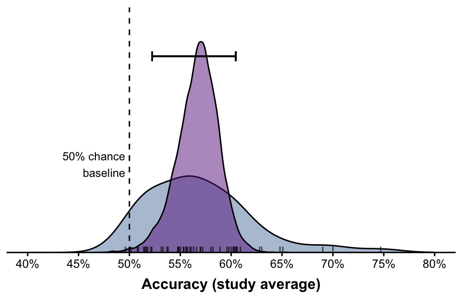

```r
# Plot core:

dens_p <- met |>
  ggplot(aes(x = accuracy)) +
  geom_density(fill = default_col2, alpha = 0.8) +
  geom_density(data = posts_int,
               mapping = aes(x = int),
               fill = default_col, alpha = 0.5) +
  geom_vline(xintercept = 50, linetype = 'dashed') +
  geom_rug(alpha = 0.6, length = unit(0.024, 'npc'))

# Scales, axes, and annotations:

dens_p <- dens_p +
  scale_x_continuous(limits = c(40, 80),
                     breaks = seq(40, 80, 5),
                     labels = str_c(seq(40, 80, 5), '%')) +
  scale_y_continuous(expand = c(0, 0), limits = c(0, 0.25),
                     breaks = seq(0, 0.25, 0.05)) +
  xlab('Accuracy (study average)') +
  # ylab('Probability density') +
  ylab(NULL) +
  annotate('text', x = 49.6, y = 0.09,
           label = '50% chance\nbaseline',
           hjust = 1,
           size = 3)

# With 95% credible interval of the mean:

dens_p <- dens_p +
  geom_errorbarh(aes(xmin = 0.5223956 * 100,
           xmax = 0.6043825 * 100,
           y = 0.2),
           height = 0.01)
# Plot cosmetics:

dens_p <- dens_p +
  theme_classic() +
  theme(axis.title.x = element_text(face = 'bold', margin = margin(t = 6))) +
  # theme(axis.title.y = element_text(margin = margin(r = 10))) +
  theme(axis.line.y = element_blank(),
        axis.ticks.y = element_blank(),
        axis.text.y = element_blank())

# Show and save:

dens_p
```

```r
ggsave('../figures/pdf/meta_analysis_density_plot_with_posts.pdf',
       width = 6, height = 2.8)
```

```
## `height` was translated to `width`.
```

```r
ggsave('../figures/png/meta_analysis_density_plot_with_posts.png',
       width = 6, height = 2.8)
```

```
## `height` was translated to `width`.
```

## 7.2 Accuracy with antonyms

Extract the posterior for intercept and antonyms and derive the predictions for the different antonym conditions from that. Do the same for auditory:

```r
# For reference:

# mutate(antonyms_weighted = if_else(antonyms == 0, -0.722, +0.278),
#          auditory_weighted = if_else(auditory_presentation == 0, -0.426, +0.574))

# Extract posteriors and calculate conditions:

posts_int <- as_draws_df(full_mdl) |>
  select(b_Intercept, b_antonyms_weighted, b_auditory_weighted) |>
  mutate(int = plogis(b_Intercept) * 100,
         antonyms = b_Intercept + (b_antonyms_weighted * 0.278),
         no_antonyms = b_Intercept + (b_antonyms_weighted * (-0.722)),
         antonyms = plogis(antonyms) * 100,
         no_antonyms = plogis(no_antonyms) * 100)
# Show:

posts_int
```

```
## # A tibble: 32,000 × 6
##    b_Intercept b_antonyms_weighted b_auditory_weighted   int antonyms
##          <dbl>               <dbl>               <dbl> <dbl>    <dbl>
##  1       0.305              0.0885           -0.0475    57.6     58.2
##  2       0.343              0.0794           -0.0180    58.5     59.0
##  3       0.323              0.0885           -0.0183    58.0     58.6
##  4       0.298              0.104            -0.0292    57.4     58.1
##  5       0.323              0.0970           -0.0107    58.0     58.7
##  6       0.375              0.0874           -0.0253    59.3     59.8
##  7       0.405              0.0949            0.000371  60.0     60.6
##  8       0.227              0.107            -0.0181    55.6     56.4
##  9       0.223              0.0775           -0.0190    55.6     56.1
## 10       0.192              0.105            -0.0130    54.8     55.5
## # ℹ 31,990 more rows
## # ℹ 1 more variable: no_antonyms <dbl>
```

Accuracy means with superimposed posterior for antonym and no-antonym studies.

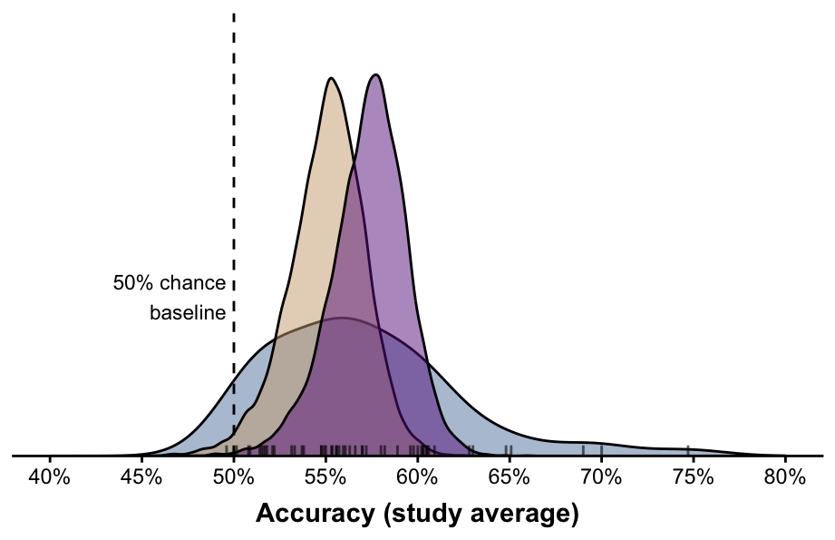

```r
# Plot core:

dens_p <- met |>
  ggplot(aes(x = accuracy)) +
  geom_density(fill = default_col2, alpha = 0.8) +
  geom_density(data = posts_int,
               mapping = aes(x = no_antonyms),
               fill = 'burlywood3', alpha = 0.5) +
  geom_density(data = posts_int,
               mapping = aes(x = antonyms),
               fill = default_col, alpha = 0.5) +
  geom_vline(xintercept = 50, linetype = 'dashed') +
  geom_rug(alpha = 0.6, length = unit(0.024, 'npc'))

# Scales, axes, and annotations:

dens_p <- dens_p +
  scale_x_continuous(limits = c(40, 80),
                     breaks = seq(40, 80, 5),
                     labels = str_c(seq(40, 80, 5), '%')) +
  scale_y_continuous(expand = c(0, 0), limits = c(0, 0.25),
                     breaks = seq(0, 0.25, 0.05)) +
  xlab('Accuracy (study average)') +
  ylab('Probability density') +
  ylab(NULL) +
  annotate('text', x = 49.6, y = 0.09,
           label = '50% chance\nbaseline',
           hjust = 1,
           size = 3)

# Plot cosmetics:

dens_p <- dens_p +
  theme_classic() +
  theme(axis.title.x = element_text(face = 'bold', margin = margin(t = 6))) +
  # theme(axis.title.y = element_text(margin = margin(r = 10))) +
  theme(axis.line.y = element_blank(),
        axis.ticks.y = element_blank(),
        axis.text.y = element_blank())

# Show and save:

dens_p
```

```r
ggsave('../figures/pdf/meta_analysis_density_plot_with_antonym_posts.pdf',
       width = 6, height = 2.8)
ggsave('../figures/png/meta_analysis_density_plot_with_antonym_posts.png',
       width = 6, height = 2.8)
```

## 7.3 Conditional effects

Extract conditional effects for antonyms - these will appear like a continuous regression line because we just supplied numerical values.

```r
antonyms_cond <- conditional_effects(full_mdl, effects = 'antonyms_weighted')[[1]]

auditory_cond <- conditional_effects(full_mdl, effects = 'auditory_weighted')[[1]]
```

Get the first and last column:

```r
antonyms_cond[1, ]$estimate__
```

```
## [1] 0.5520029
```

```r
antonyms_cond[nrow(antonyms_cond), ]$estimate__
```

```
## [1] 0.574814
```

This completes this analysis.